# Statistical Modelling Cheatsheet 02 Matching for Causal Modelling

# Introduction

This document focuses on the practical implementation of matching after causal assumptions and confounders have already been identified.

# The Causal Inference Workflow

1. Define the causal question
- Decide what exposure/treatment X and outcome Y you care about.
2. State the assumptions
- Check whether positivity, exchangeability, and consistency are plausible.
3. Draw a DAG
- Map the assumed relationships between treatment, outcome, confounders, mediators
4. Identify confounders to control for Use the DAG to find variables that affect both X and Y
5. Choose a control strategy Decide whether to use stratification, regression adjustment, matching
6. Assess balance in raw data
7. Match
8. Check balance after matching
9. Estimate treatment effect in the matched data

Step 1-3 are not covered here. This document showcases the matching process.

# Matching in Practice

The examples below use the built-in `lalonde` dataset from the `MatchIt` package, based on Robert LaLonde’s 1986 study evaluating the effect of a job training program (`treat`) on earnings in 1978 (`re78`).

```r
if (!requireNamespace("MatchIt", quietly = TRUE)) {
    install.packages("MatchIt")
}

library(MatchIt)
head(lalonde)
```

|  | treat | age | educ | race | married | nodegree | re74 | re75 | re78 |
| --- | --- | --- | --- | --- | --- | --- | --- | --- | --- |
| NSW1 | 1 | 37 | 11 | black | 1 | 1 | 0 | 0 | 9930.0460 |
| NSW2 | 1 | 22 | 9 | hispan | 0 | 1 | 0 | 0 | 3595.8940 |
| NSW3 | 1 | 30 | 12 | black | 0 | 0 | 0 | 0 | 24909.4500 |
| NSW4 | 1 | 27 | 11 | black | 0 | 1 | 0 | 0 | 7506.1460 |
| NSW5 | 1 | 33 | 8 | black | 0 | 1 | 0 | 0 | 289.7899 |
| NSW6 | 1 | 22 | 9 | black | 0 | 1 | 0 | 0 | 4056.4940 |

# Prematching balance check

Runs a bivariate comparison of each covariate (age, educ, race, married, nodegree, re74, re75) across the two treatment groups (treat = 0 vs treat = 1).

[CompareGroups docs](https://cran.r-project.org/web/packages/compareGroups/vignettes/compareGroups_vignette.html)

```r
library(compareGroups)
comp <- compareGroups(treat ~ age + educ + race + married + nodegree + re74 + re75, data = lalonde)

createTable(comp, show.p.overall = FALSE)
```

```
##
## --------Summary descriptives table by 'treat'---------
##
## __________________________________
##                 0           1
##               N=429       N=185
## ¯¯¯¯¯¯¯¯¯¯¯¯¯¯¯¯¯¯¯¯¯¯¯¯¯¯¯¯¯¯¯¯¯¯
## age        28.0 (10.8) 25.8 (7.16)
## educ       10.2 (2.86) 10.3 (2.01)
## race:
##     black  87 (20.3%)  156 (84.3%)
##     hispan 61 (14.2%)  11 (5.95%)
##     white  281 (65.5%) 18 (9.73%)
## married    0.51 (0.50) 0.19 (0.39)
## nodegree   0.60 (0.49) 0.71 (0.46)
## re74       5619 (6789) 2096 (4887)
## re75       2466 (3292) 1532 (3219)
## ¯¯¯¯¯¯¯¯¯¯¯¯¯¯¯¯¯¯¯¯¯¯¯¯¯¯¯¯¯¯¯¯¯¯
```

The dataset also contains demographic variables, like age, education, race and marital status, as well as earnings in the years before the program began.

Program participants were younger, more likely to be Black, unmarried and have no degree. The background characteristics are clearly unbalanced and potentially bias the estimate of interest.

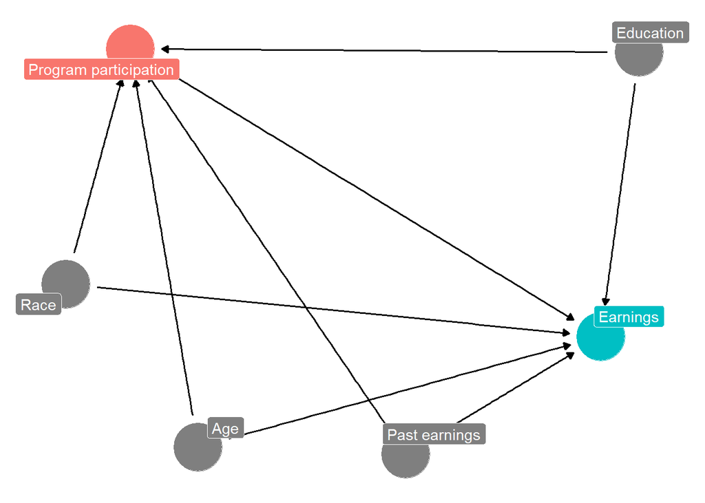

This DAG represents the belief that different background characteristics influence the chances of program participation, and that these characteristics might also influnce earnings.

If the treated and control groups differ substantially on covariates, it signals confounding, motivating the use of methods like propensity score matching to achieve balance.

# Perform Matching

We can use the matchit() function from the MatchIt package to matche treated individuals to controls with similar background characteristics.

```r
set.seed(54321) # For reproducibility
match <- matchit(treat ~ age + educ + race + married + nodegree + re74 + re75,
                  method = 'nearest',
                  distance = 'glm',
                  ratio = 1,
                  data = lalonde)
```

This code implements 1:1 propensity score matching using the nearest neighbour algorithm. To check the success of the matching we can use the cobalt package to compare the balance of background characteristics before and after matching.

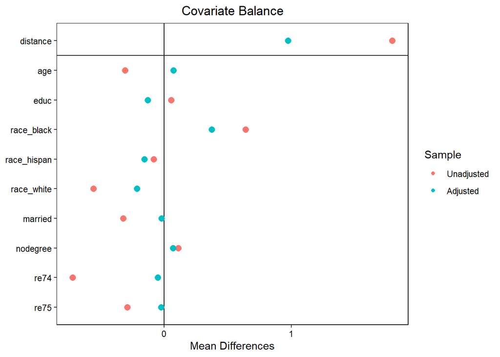

```r
cobalt::love.plot(match)
```

The love plot shows the mean differences between treated and control samples before and after matching. After matching (i.e. the adjusted sample) the mean differences are closer to 0, indicating that the balance is improved.

Compare results in the matched and un matched dataset.

```r
# Extract the matched data
lalondeMatched <- match.data(match)

# Fit models in the raw and matched data
m_raw <- lm(re78 ~ treat, data = lalonde)
m_adjusted <- lm(re78 ~ treat, data = lalondeMatched)

# Compare the model estimates
sjPlot::tab_model(m_raw, m_adjusted, digits=0, show.p = FALSE, show.r2 = FALSE, dv.labels = c("Model 1: Original data", "Model 2: Matched data"))
```

|  | Model 1: Original data |  | Model 2: Matched data |  |
| --- | --- | --- | --- | --- |
| Predictors | Estimates | CI | Estimates | CI |
| (Intercept) | 6984 | 6276 – 7693 | 5455 | 4439 – 6470 |
| treat | -635 | -1926 – 655 | 894 | -542 – 2330 |
| Observations | 614 |  | 370 |  |